# Signal Evaluation Demo - Single Hold Out

Evaluating the efficacy of a Signal over a single hold out period

Author

Mike Aguilar | https://www.linkedin.com/in/mike-aguilar-econ/

# Background

This file demonstrates how to use the function signal_evaluation_singleholdout, which is custom built for our class.

For this demo we will simulate some trading data, use signal_evaluation_singleholdout to evaluate, and then interpret the performance stats.

# Data

## Tickers

**CautionTask**

Task: Set a seed for consistent randomization

```r
set.seed(123)
```

**CautionTask**

Task: Create a vector of 300 ticker labels of the form A001, A002, …, A300

```r
N <- 300
tickers <- paste0("A", sprintf("%03d", 1:N))
```

**NoteOutput**

```
  [1] "A001" "A002" "A003" "A004" "A005" "A006" "A007" "A008" "A009" "A010"
 [11] "A011" "A012" "A013" "A014" "A015" "A016" "A017" "A018" "A019" "A020"
 [21] "A021" "A022" "A023" "A024" "A025" "A026" "A027" "A028" "A029" "A030"
 [31] "A031" "A032" "A033" "A034" "A035" "A036" "A037" "A038" "A039" "A040"
 [41] "A041" "A042" "A043" "A044" "A045" "A046" "A047" "A048" "A049" "A050"
 [51] "A051" "A052" "A053" "A054" "A055" "A056" "A057" "A058" "A059" "A060"
 [61] "A061" "A062" "A063" "A064" "A065" "A066" "A067" "A068" "A069" "A070"
 [71] "A071" "A072" "A073" "A074" "A075" "A076" "A077" "A078" "A079" "A080"
 [81] "A081" "A082" "A083" "A084" "A085" "A086" "A087" "A088" "A089" "A090"
 [91] "A091" "A092" "A093" "A094" "A095" "A096" "A097" "A098" "A099" "A100"
[101] "A101" "A102" "A103" "A104" "A105" "A106" "A107" "A108" "A109" "A110"
[111] "A111" "A112" "A113" "A114" "A115" "A116" "A117" "A118" "A119" "A120"
[121] "A121" "A122" "A123" "A124" "A125" "A126" "A127" "A128" "A129" "A130"
[131] "A131" "A132" "A133" "A134" "A135" "A136" "A137" "A138" "A139" "A140"
[141] "A141" "A142" "A143" "A144" "A145" "A146" "A147" "A148" "A149" "A150"
[151] "A151" "A152" "A153" "A154" "A155" "A156" "A157" "A158" "A159" "A160"
[161] "A161" "A162" "A163" "A164" "A165" "A166" "A167" "A168" "A169" "A170"
[171] "A171" "A172" "A173" "A174" "A175" "A176" "A177" "A178" "A179" "A180"
[181] "A181" "A182" "A183" "A184" "A185" "A186" "A187" "A188" "A189" "A190"
[191] "A191" "A192" "A193" "A194" "A195" "A196" "A197" "A198" "A199" "A200"
[201] "A201" "A202" "A203" "A204" "A205" "A206" "A207" "A208" "A209" "A210"
[211] "A211" "A212" "A213" "A214" "A215" "A216" "A217" "A218" "A219" "A220"
[221] "A221" "A222" "A223" "A224" "A225" "A226" "A227" "A228" "A229" "A230"
[231] "A231" "A232" "A233" "A234" "A235" "A236" "A237" "A238" "A239" "A240"
[241] "A241" "A242" "A243" "A244" "A245" "A246" "A247" "A248" "A249" "A250"
[251] "A251" "A252" "A253" "A254" "A255" "A256" "A257" "A258" "A259" "A260"
[261] "A261" "A262" "A263" "A264" "A265" "A266" "A267" "A268" "A269" "A270"
[271] "A271" "A272" "A273" "A274" "A275" "A276" "A277" "A278" "A279" "A280"
[281] "A281" "A282" "A283" "A284" "A285" "A286" "A287" "A288" "A289" "A290"
[291] "A291" "A292" "A293" "A294" "A295" "A296" "A297" "A298" "A299" "A300"
```

## Signal

**CautionTask**

Task: Generate a signal_matrix of length N from a N(0,1) distribution, representing the signal strength

```r
signal_matrix_vec <- rnorm(N, mean = 0, sd = 1)
```

**NoteOutput**

```
[1] -0.56047565 -0.23017749  1.55870831  0.07050839  0.12928774  1.71506499
```

**CautionTask**

Task: Create a signal_position vector based on the signal_matrix, assigning 1 for values above tau, -1 for values below -tau, and 0 otherwise. Let’s set tau = 0.05 for now.

```r
  tau <- 0.05
  signal_position_vec <- ifelse(signal_matrix_vec >  tau,  1,
                                ifelse(signal_matrix_vec < -tau, -1, 0))
```

**NoteOutput**

```
[1] -1 -1  1  1  1  1
```

## Returns

**CautionTask**

Task: Generate test period returns from a linear model loosely related to signal strength. ret = 0.01*signal + N(0,0.05) noise

```r
  eps <- rnorm(N, 0, 0.05)
  ret_simple <- 0.01 * signal_matrix_vec + eps
```

**NoteOutput**

```
[1] -0.04136687 -0.03993622 -0.03133985 -0.05192058 -0.02056510  0.03370961
```

## Combine

**CautionTask**

Task: Format the signal_position and test_returns as data frames with ticker labels

```r
  signal_position <- data.frame(ticker = tickers, signal_position = signal_position_vec)
  test_returns <- data.frame(ticker = tickers, test_returns = ret_simple)
```

**NoteOutput**

```
  ticker test_returns
1   A001  -0.04136687
2   A002  -0.03993622
3   A003  -0.03133985
4   A004  -0.05192058
5   A005  -0.02056510
6   A006   0.03370961
```

**CautionTask**

Task: Format the meta data for labels

```r
  Meta <- list(assetname = "asset", benchmarkname = "market", signalname = "Momentum")
```

**NoteOutput**

```
$assetname
[1] "asset"

$benchmarkname
[1] "market"

$signalname
[1] "Momentum"
```

# Signal

When you are implementing in practice, you likely won’t be simulating the returns and signals as we did above. Instead, you’d be using observed data to generate those objects.

Now that we have the data for the asset returns and signal generated, let’s evalaute the signal.

## Call to Signal Evaluator

**CautionTask**

Task: Set the threshold for classification to .25%

```r
return_threshold <- 0.0025
```

**TipQuestion**

Q: What’s the meaning of this return_threshold within our case?

**NoteAnswer**

A: Here, `return_threshold = 0.0025` creates a 0.25% neutral band around zero. The function classifies each realized test-period return as:

- **Positive:** return > +0.25%
- **Neutral:** -0.25% $\leq$ return $\leq$ +0.25%
- **Negative:** return < -0.25%

The threshold defines how large a return must be before we treat it as meaningfully positive or negative. For example, a long signal is a correct positive classification only when the subsequent return exceeds +0.25%; a return inside the neutral band is classified as neutral. The threshold is used in the return buckets and confusion-matrix analysis.

**CautionTask**

```r
  SignalEval <- signal_evaluation_singleholdout(
    test_returns = test_returns,
    Meta = Meta,
    return_threshold = return_threshold,
    signal_position = signal_position
  )
```

## Signal Evaluation

In this subsection we will call selective components of the SignalEval object and interpret the efficacy of our signal.

**CautionTask**

Task: Display the TradeResults and their accompanying percent table.

```r
SignalEval$TradeResults
SignalEval$TradeResults_Percent
```

**NoteOutput**

```
# A tibble: 4 × 5
  `Test Period Returns`         Long Neutral Short   Sum
  <chr>                        <int>   <int> <int> <int>
1 r > threshold                   77       3    68   148
2 -threshold <= r <= threshold     5       2     7    14
3 r < -threshold                  59       5    74   138
4 Sum                            141      10   149   300
```

```
# A tibble: 4 × 5
  `Test Period Returns`         Long Neutral Short   Sum
  <chr>                        <dbl>   <dbl> <dbl> <dbl>
1 r > threshold                0.257   0.01  0.227 0.493
2 -threshold <= r <= threshold 0.017   0.007 0.023 0.047
3 r < -threshold               0.197   0.017 0.247 0.46
4 Sum                          0.47    0.033 0.497 1
```

**TipQuestion**

Q: Interpret the first row of the Percent table

**NoteAnswer**

A:

- .257: In 25.7% of all observations we went long & there were positive test period returns
- 0.01: In 1% of all observations we didn’t trade and there were positive test period returns
- 0.227: In 22.7% of all observations we went short and there were positive test period returns
- 0.493: In 49.3% of all observations where were positive test period returns

**CautionTask**

Task: Display the return comparison table

```r
SignalEval$return_comparison
```

**NoteOutput**

```
# A tibble: 4 × 6
  comparison              Avg_Ret t_stat p_one_sided   n_A   n_B
  <chr>                     <dbl>  <dbl>       <dbl> <int> <int>
1 Long vs Not-Long        0.00944  1.64       0.0512   141   159
2 Short vs Not-Short     -0.00715 -1.25       0.893    149   151
3 Neutral vs Not-Neutral -0.0175  -0.900      0.805     10   290
4 Long vs Short           0.00860  1.48       0.0696   141   149
```

**TipQuestion**

Q: Interpret the Long vs Short results

**NoteAnswer**

A: The difference in mean returns between long and short returns is 0.0086, indicating that on average, long positions outperformed short positions by 0.86%. The p-value of 0.0696 suggests that this difference is marginally statistically significant at the 10% level, indicating some evidence that the signal has predictive power over test period returns.

**CautionTask**

Task: Display the violin plots of test returns by signal, outcome, and all combos

```r
SignalEval$plots$signal
SignalEval$plots$facet
SignalEval$plots$combo
```

**NoteOutput**

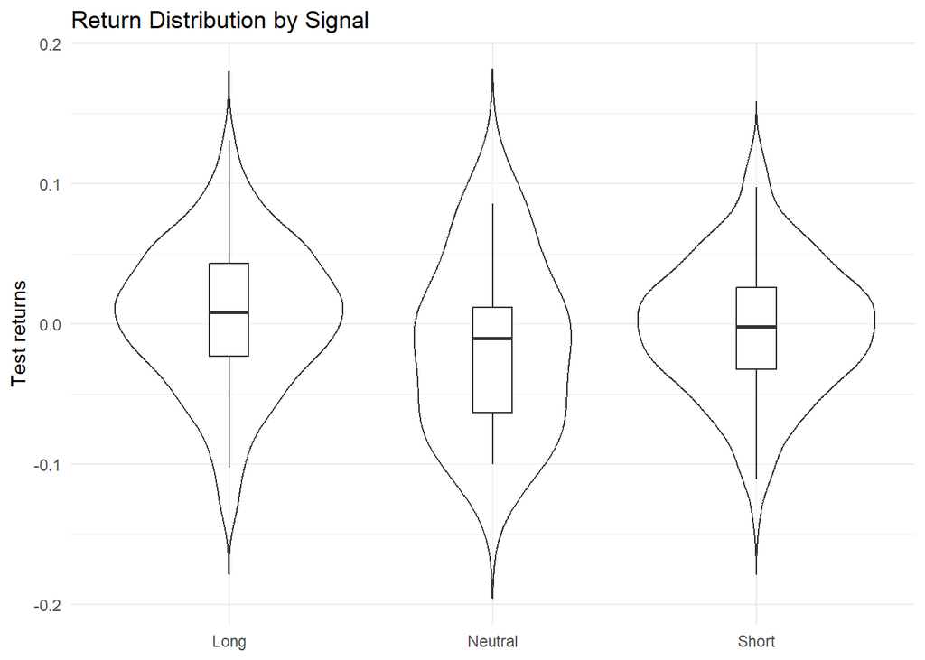

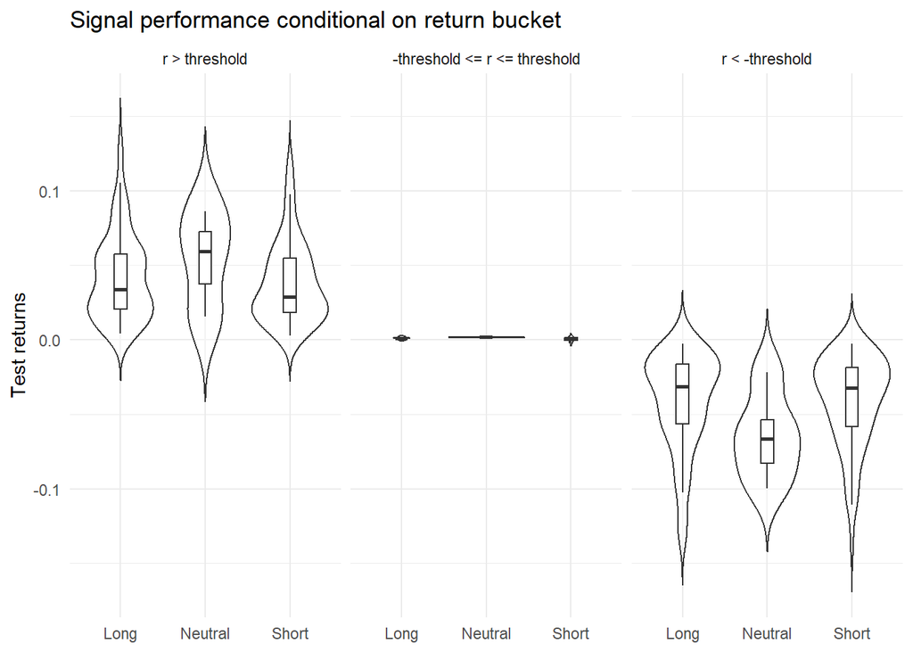

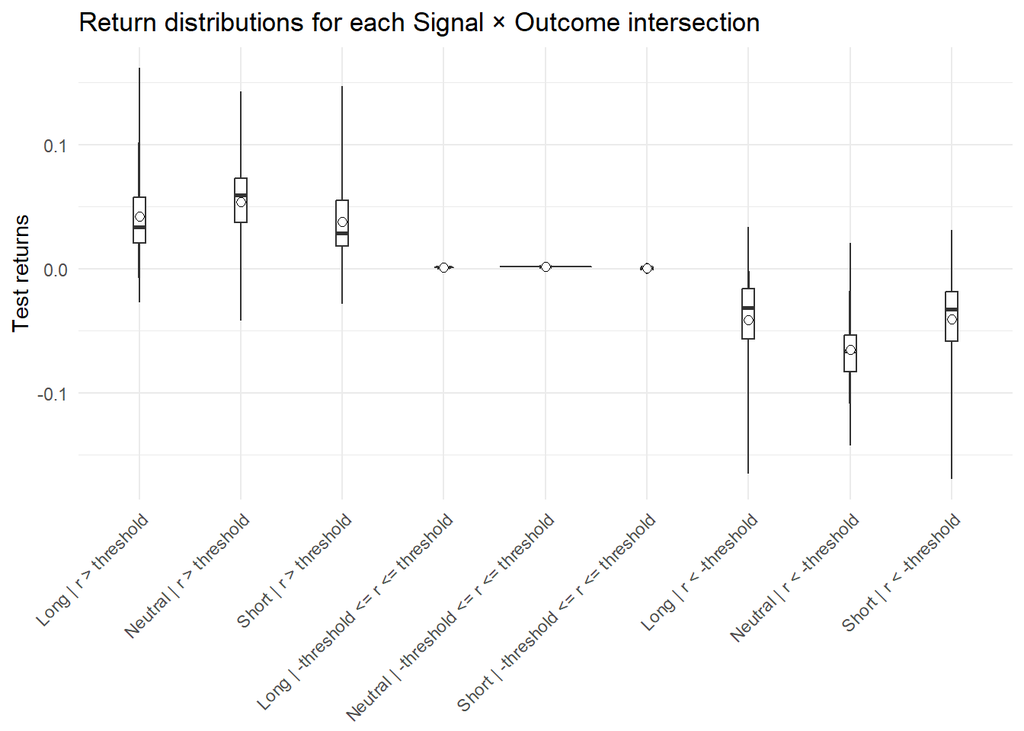

**CautionTask**

Task: Display summary table of sample stats

```r
SignalEval$summary_table
```

**NoteOutput**

```
                                    group   n   mean    sd   skew   kurt    min
1                                 overall 300  0.001 0.050 -0.160 -0.098 -0.136
2                                    Long 141  0.006 0.051 -0.264 -0.009 -0.129
3                                 Neutral  10 -0.016 0.061  0.207 -1.386 -0.100
4                                   Short 149 -0.003 0.048 -0.097 -0.066 -0.136
5            -threshold <= r <= threshold  14  0.001 0.001 -0.872 -0.368 -0.002
6                          r < -threshold 138 -0.042 0.032 -0.925  0.179 -0.136
7                           r > threshold 148  0.041 0.028  0.895  0.300  0.003
8     Long | -threshold <= r <= threshold   5  0.001 0.001 -0.138 -1.538  0.000
9                   Long | r < -threshold  59 -0.042 0.033 -0.994  0.224 -0.129
10                   Long | r > threshold  77  0.042 0.029  0.841  0.236  0.004
11 Neutral | -threshold <= r <= threshold   2  0.002 0.000     NA     NA  0.002
12               Neutral | r < -threshold   5 -0.065 0.030  0.257 -1.695 -0.100
13                Neutral | r > threshold   3  0.054 0.036 -0.156     NA  0.015
14   Short | -threshold <= r <= threshold   7  0.000 0.001 -0.395 -1.581 -0.002
```

[output cut: 19 more lines]

**CautionTask**

Task: Display Info Coefficient

```r
SignalEval$summary_ic_tbl
```

**NoteOutput**

```
# A tibble: 4 × 3
  Metric       All Acted_Only
  <chr>      <dbl>      <dbl>
1 IC        0.0847      0.087
2 t-stat    1.47        1.48
3 p-value   0.143       0.139
4 N       300         290
```

**TipQuestion**

Q: What does the IC all mean? Is it statistically significant?

**NoteAnswer**

A:

- IC captures the correlation between the signal and test period returns
- The IC of 0.0847 has a p value of 0.1432, implying that we fail to reject the null that IC = 0, suggesting that the signal has little predictive power over test period returns
- Note that the results are similar if we focus only on the observations where we took a position (Acted Only)

**CautionTask**

Task: Display the Hit Rate

```r
SignalEval$hit_table
```

**NoteOutput**

```
# A tibble: 6 × 3
  Metric   Overall ActedOnly
  <chr>      <dbl>     <dbl>
1 Hit rate   0.527     0.545
2 Hits     158       158
3 N        300       290
4 z          0.924     1.53
5 p-value    0.356     0.127
6 Coverage   0.967     0.967
```

**TipQuestion**

Q: What does the Hit Rate mean? What does the p value and Coverage suggest?

**NoteAnswer**

A:

- The Hit Rate of .52 implies that for 52% of the observations our position correctly predicted the direction of test period returns.
- The p value of .356 suggests that we fail to reject the null that Hit Rate = 0.5, indicating that the signal has little predictive power over test period returns
- The coverage of .966 implies that we were active roughly 96% of the observations.

**CautionTask**

Task: Display the confusion matrix

```r
SignalEval$confusion_report
```

**NoteOutput**

```
# A tibble: 13 × 4
   Metric      `Long vs Not-Long` `Short vs Not-Short` `Neutral vs Not-Neutral`
   <fct>                    <dbl>                <dbl>                    <dbl>
 1 TP                       77                   74                        2
 2 FP                       59                   68                        8
 3 FN                       71                   64                       12
 4 TN                       79                   80                      278
 5 accuracy                  0.55                 0.54                     0.93
 6 precision                 0.57                 0.52                     0.2
 7 recall                    0.52                 0.54                     0.14
 8 specificity               0.57                 0.54                     0.97
 9 type1_error               0.43                 0.46                     0.03
10 type2_error               0.48                 0.46                     0.86
11 f1                        0.54                 0.53                     0.17
12 mcc                       0.09                 0.08                     0.14
13 <NA>                    286                  286                      300
```

**TipQuestion**

Q: Interpret each of the metrics for Long positions

**NoteAnswer**

A:

For this table, a **predicted positive** means that the signal told us to go long. An **actual positive** means that the test-period return exceeded +0.25%, while an **actual negative** means that it fell below -0.25%. A “not-long” signal is either neutral or short.

- **TP (True Positive = 77):** We went long, and the test-period return exceeded +0.25%.
- **FP (False Positive = 59):** We went long, but the test-period return fell below -0.25%.
- **FN (False Negative = 71):** We did not go long, but the test-period return exceeded +0.25%.
- **TN (True Negative = 79):** We did not go long, and the test-period return fell below -0.25%.
- **n (286):** The number of observations used in the long-versus-not-long classification: $77+59+71+79=286$. The other 14 of the original 300 observations had returns inside the neutral band and are excluded from this particular confusion matrix.
- **Accuracy (0.55):** Approximately 55% of the included observations were classified correctly: $(TP+TN)/n$.
- **Precision (0.57):** Among the observations for which we went long, 57% subsequently earned a return above +0.25%: $TP/(TP+FP)$.
- **Recall (0.52):** Among the observations whose returns exceeded +0.25%, we went long 52% of the time: $TP/(TP+FN)$.
- **Specificity (0.57):** Among the observations whose returns fell below -0.25%, we did not go long 57% of the time: $TN/(TN+FP)$.
- **Type I error (0.43):** Among the observations whose returns fell below -0.25%, we nevertheless went long 43% of the time: $FP/(FP+TN)=1-\text{specificity}$.
- **Type II error (0.48):** Among the observations whose returns exceeded +0.25%, we failed to go long 48% of the time: $FN/(FN+TP)=1-\text{recall}$.
- **F1 score (0.54):** The harmonic mean of precision and recall. It summarizes how well the long signal identifies large positive returns while limiting incorrect long signals; higher is better.
- **MCC (0.09):** The Matthews correlation coefficient summarizes all four confusion-matrix cells and ranges from -1 to +1. A value near zero indicates little classification skill; 0.09 therefore suggests only a weak positive relationship between the long signal and large positive test-period returns.